# Types of Data, R Commands, and Graphics

Class Activity

Andrew Seaman

2025-Jan-23

## Useful with Numerical or Categorical Data?

*Consider each of the following R Commands and explain if they would best be used with Quantitative data or Categorical data.*

#### a. table(…)

Best used with categorical data to see quantitative data ordered.

###### Example:

```r
# Example:

table(KidsFeet$birthmonth)
```

```
##
##  1  2  3  4  5  6  7  8  9 10 11 12
##  2  3  8  3  2  4  3  2  5  2  2  3
```

#### b. group_by(…)

Best used on numerical data using categorical data to apply the aggregate function to distinct groups.

###### Example:

```r
# Example:

df_group_by <- KidsFeet %>%
  group_by(sex) %>%
  summarise(
    calculation = mean(width)
  )

pander(df_group_by)
```

| sex | calculation |
| --- | --- |
| B | 9.19 |
| G | 8.784 |

#### c. summarise(…)

Best used on numerical data.

###### Example:

```r
# Example:

df_summarize <- KidsFeet %>%
  group_by(sex) %>%
  summarize(
    MedianLength = median(length, na.rm = TRUE),
    MedianWidth = median(width, na.rm = TRUE)
  )

pander(df_summarize)
```

| sex | MedianLength | MedianWidth |
| --- | --- | --- |
| B | 24.95 | 9.15 |
| G | 24.2 | 8.8 |

## Which Data for Which Chart?

*Consider each of the following Graphics and explain which use Quantitative data, which use Categorical data, and which use both data.*

#### a. Histogram

- **Data:** Numerical Only

###### Example:

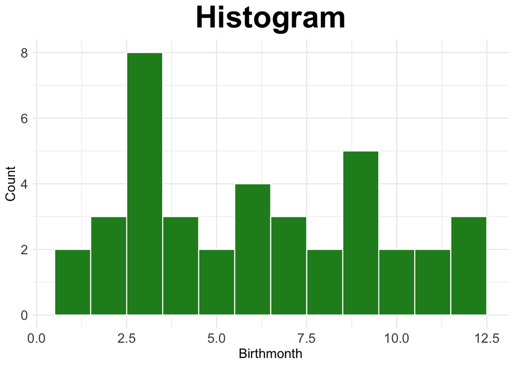

```r
# Example:

KidsFeet %>%
  ggplot(aes(x=birthmonth))+
  geom_histogram(binwidth = 1, color = "white", fill = "forestgreen") +
  labs(
    title = "Histogram",
    x = "Birthmonth",
    y = "Count"
  ) +
  theme_minimal() +
  theme(
    plot.title = element_text(
      face = "bold",
      hjust = 0.5,
      size = 30
    ),
    axis.title.x = element_text(
      size  = 13
    ),
    axis.title.y = element_text(
      size = 13
    ),
    axis.text = element_text(
      size = 13
    )
  )
```

#### b. Boxplot

- **Data:** Numerical & Categorical

###### Example:

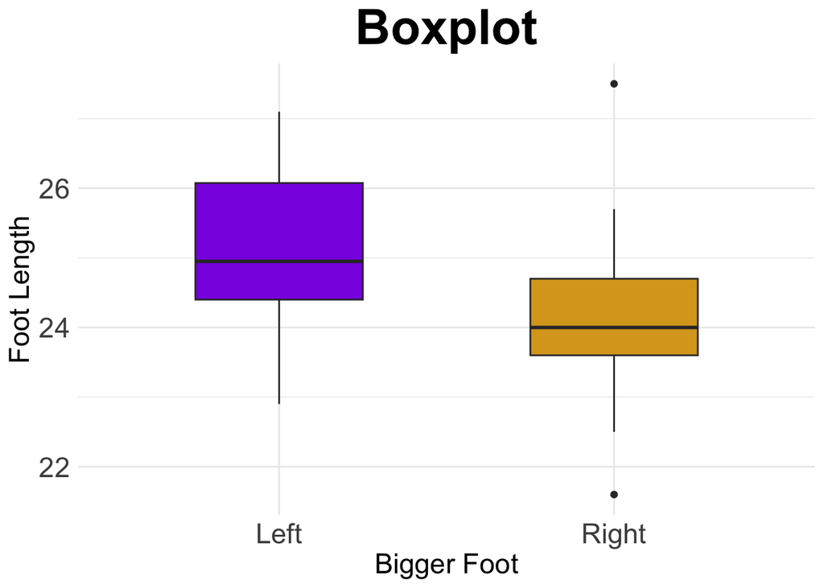

```r
# Example:

KidsFeet %>%
  ggplot(aes(x = biggerfoot, y = length, fill = biggerfoot)) +
  geom_boxplot(width = 0.5) +
  scale_fill_manual(values = c("L" = "blueviolet", "R" = "goldenrod")) +
  scale_x_discrete(labels = c("L" = "Left", "R" = "Right")) +
  labs(
    title = "Boxplot",
    x = "Bigger Foot",
    y = "Foot Length"
  ) +
  theme_minimal() +
  theme(
    legend.position = "none",
    plot.title = element_text(
      face = "bold",
      hjust = 0.5,
      size = 30
    ),
    axis.title.x = element_text(
      size  = 17
    ),
    axis.title.y = element_text(
      size = 17
    ),
    axis.text = element_text(
      size = 17
    )
  )
```

#### c. Dot plot

- **Data:** Numerical & Categorical

###### Example:

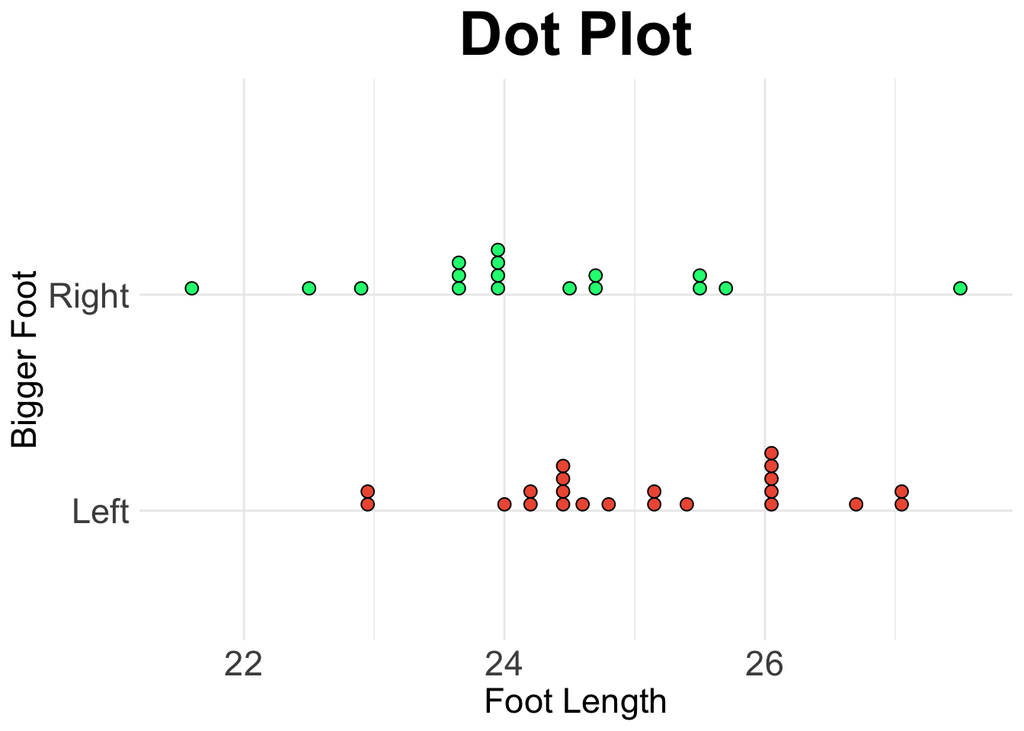

```r
# Example:

KidsFeet %>%
  ggplot(aes(x = length, y = biggerfoot, fill = biggerfoot)) +
  geom_dotplot(dotsize = .5) +
  scale_fill_manual(values = c("L" = "tomato2", "R" = "springgreen")) +
  scale_y_discrete(labels = c("L" = "Left", "R" = "Right")) +
  labs(
    title = "Dot Plot",
    x = "Foot Length",
    y = "Bigger Foot"
  ) +
  theme_minimal() +
  theme(
    legend.position = "none",
    plot.title = element_text(
      face = "bold",
      hjust = 0.5,
      size = 30
    ),
    axis.title.x = element_text(
      size  = 17
    ),
    axis.title.y = element_text(
      size = 17
    ),
    axis.text = element_text(
      size = 17
    )
  )
```

#### d. Scatterplot

- **Data:** Numerical Only

###### Example:

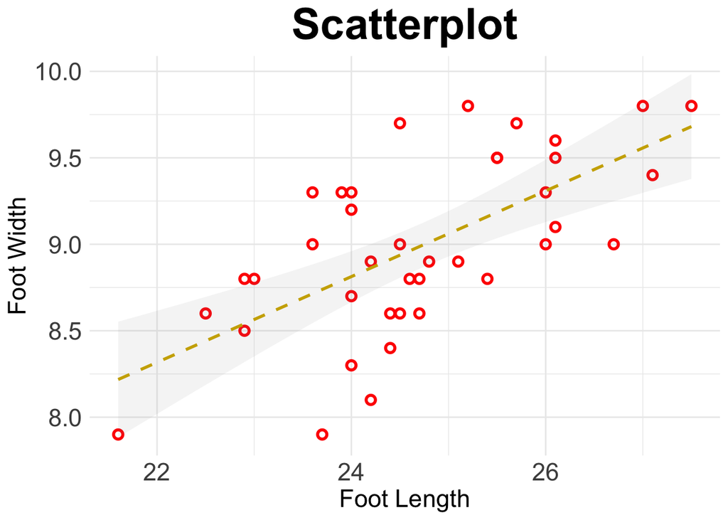

```r
# Example:

KidsFeet %>%
  ggplot(aes(x = length, y = width)) +
  geom_point(pch = 1, color = "red", size = 2, stroke = 1.5) +
  geom_smooth(method = "lm", linetype = "dashed", color = "gold3", alpha = .1) +
  labs(
    title = "Scatterplot",
    x = "Foot Length",
    y = "Foot Width"
  ) +
  theme_minimal() +
  theme(
    legend.position = "none",
    plot.title = element_text(
      face = "bold",
      hjust = 0.5,
      size = 30
    ),
    axis.title.x = element_text(
      size  = 17
    ),
    axis.title.y = element_text(
      size = 17
    ),
    axis.text = element_text(
      size = 17
    )
  )
```

#### e. Bar plot

- **Data:**
  - e1. Categorical & Numerical (for bar height); or
  - e2. Categorical only (if showing frequency)

###### Example e1:

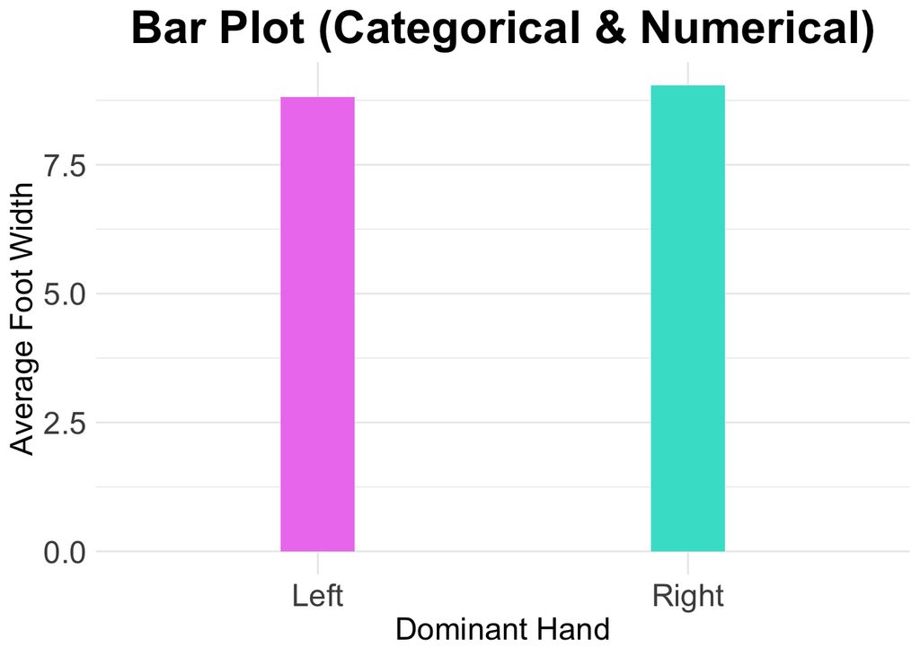

```r
# Example e1:

KidsFeet %>%
  group_by(domhand) %>%
  summarise(Average_Width = mean(width, na.rm = TRUE)) %>%
  ggplot(aes(x = domhand, y = Average_Width, fill = domhand)) +
  geom_col(width = .2) +
  scale_fill_manual(values  = c("L" = "violet", "R" = "turquoise")) +
  scale_x_discrete(labels = c("L" = "Left", "R" = "Right")) +
  labs(
    title = "Bar Plot (Categorical & Numerical)",
    x = "Dominant Hand",
    y = "Average Foot Width"
  ) +
  theme_minimal() +
  theme(
    legend.position = "none",
    plot.title = element_text(
      face = "bold",
      hjust = 0.5,
      size = 25
    ),
    axis.title.x = element_text(
      size  = 17
    ),
    axis.title.y = element_text(
      size = 17
    ),
    axis.text = element_text(
      size = 17
    )
  )
```

###### Example e2:

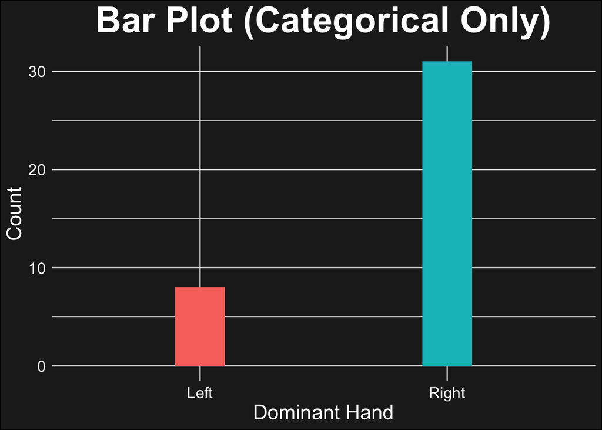

```r
# Example e2:

KidsFeet %>%
  ggplot(aes(x = domhand, fill = domhand)) +
  geom_bar(width = .2) +
  scale_x_discrete(labels = c("L" = "Left", "R" = "Right")) +
  labs(
    title = "Bar Plot (Categorical Only)",
    x = "Dominant Hand",
    y = "Count"
  ) +
  theme_minimal() +
  theme(
    plot.title = element_text(
      face = "bold",
      hjust = 0.5,
      size = 30,
      color = "white"
    ),
    axis.title.x = element_text(
      size  = 17,
      color = "white"
    ),
    axis.title.y = element_text(
      size = 17,
      color = "white"
    ),
    axis.text = element_text(
      size = 13,
      color = "white"
    ),
    legend.position = "none",
    plot.background = element_rect(
      # color = "black",
      # linewidth = 0.2,
      # fill = "lightgray",
      alpha("black", alpha = 0.9)
    )
  #   plot.margin = margin(20, 20, 20, 20)  # Top, Right, Bottom, Left padding
  )
```

## Answer the Question with Data and Graphics

*Identify the (1) type of data, (2) R Commands, and (3) Graphic that could be used to answer each of the following questions.*

#### a. Does the width of a child’s foot predict whether or not they are right-handed?

- **Data:** Numerical and Categorical
- **Graphic:** Boxplot

###### Example:

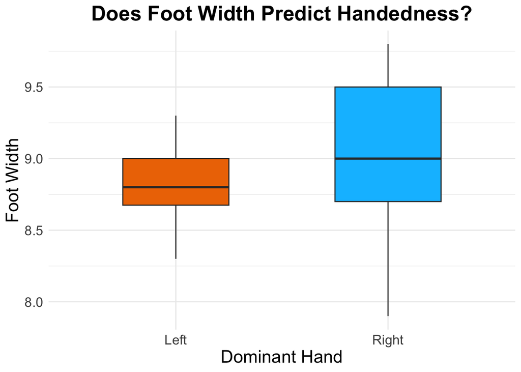

```r
# Example:

KidsFeet %>%
  ggplot(aes(x = domhand, y = width, fill = domhand)) +
  geom_boxplot(width = .5) +
  scale_fill_manual(values = c("L" = "darkorange2", "R" = "deepskyblue")) +
  scale_x_discrete(labels = c("L" = "Left", "R" = "Right")) +
  labs(
    title = "Does Foot Width Predict Handedness?",
    x = "Dominant Hand",
    y = "Foot Width"
  ) +
  theme_minimal() +
  theme(
    legend.position = "none",
    plot.title = element_text(
      face = "bold",
      hjust = 0.5,
      size = 20
    ),
    axis.title.x = element_text(
      size  = 17
    ),
    axis.title.y = element_text(
      size = 17
    ),
    axis.text = element_text(
      size = 13
    )
  )
```

#### b. Is one gender more likely to be born in certain seasons of the year?

- **Data:** Categorical & Numerical
- **Graphic:** Bargraph

###### Example:

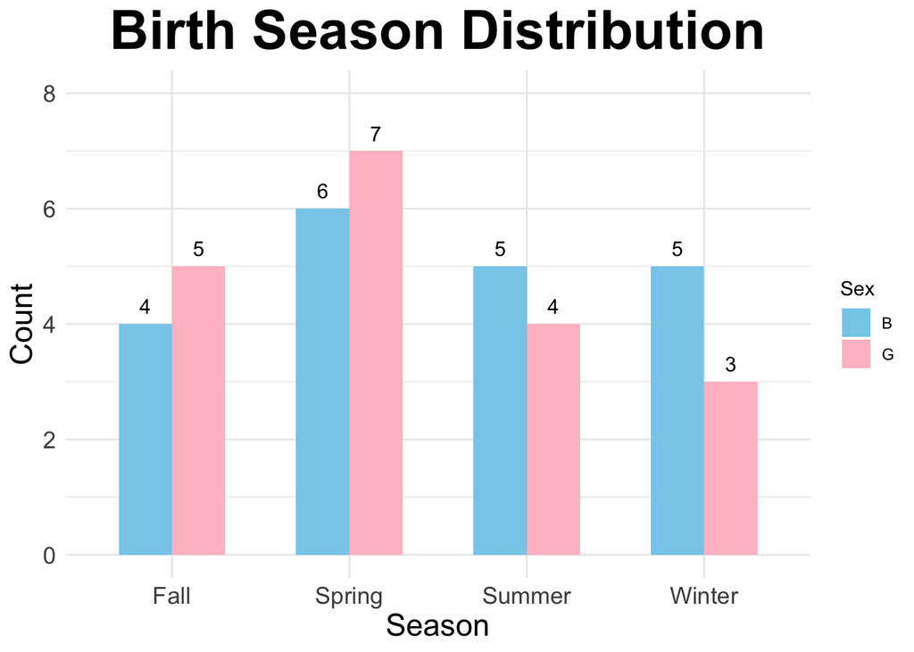

```r
# Example:

KidsFeet %>%
  mutate(
    season = case_when(
      birthmonth %in% c(12, 1, 2) ~ "Winter",
      birthmonth %in% c(3, 4, 5) ~ "Spring",
      birthmonth %in% c(6, 7, 8) ~ "Summer",
      birthmonth %in% c(9, 10, 11) ~ "Fall"
    )
  ) %>%
  ggplot(aes(x = season, fill = sex)) +
  geom_bar(position = "dodge", width = 0.6) +
  scale_y_continuous(limits = c(0, 8)) +
  geom_text(
    stat = "count",
    aes(label = after_stat(count)),
    position = position_dodge(width = 0.6),
    vjust = - 0.7,
    size = 4
  ) +
  scale_fill_manual(values = c("B" = "skyblue", "G" = "pink")) + # Correct way to assign colors
  labs(
    title = "Birth Season Distribution",
    x = "Season",
    y = "Count",
    fill = "Sex"
  ) +
  theme_minimal() +
  theme(
    plot.title = element_text(
      face = "bold",
      hjust = 0.5,
      size = 30
    ),
    axis.title.x = element_text(
      size  = 17
    ),
    axis.title.y = element_text(
      size = 17
    ),
    axis.text = element_text(
      size = 13
    )
  )
```

#### c. How many boys (B) and how many girls (G) are in the KidsFeet dataset?

- **Data:** Categorical
- **Graphic:** Bargraph

###### Example:

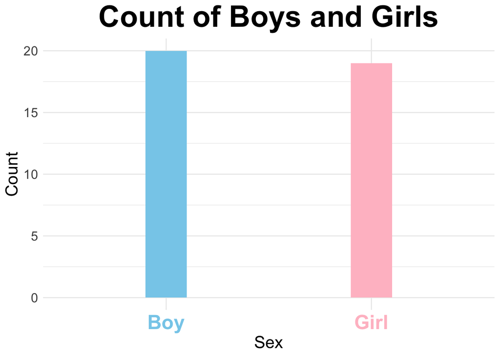

```r
# Example:

KidsFeet %>%
  ggplot(aes(x = sex, fill = sex)) +
  geom_bar(position = "dodge", width = .2) +
  scale_fill_manual(values = c("B" = "skyblue", "G" = "pink")) +
  labs(
    title = "Count of Boys and Girls",
    x = "Sex",
    y = "Count"
  ) +
  scale_x_discrete(
    labels = c("B" = "Boy", "G" = "Girl")
  ) +
  theme_minimal() +
  theme(
    plot.title = element_text(
      face = "bold",
      hjust = 0.5,
      size = 30
    ),
    axis.title.x = element_text(
      size = 17
    ),
    axis.title.y = element_text(
      size = 17
    ),
    axis.text = element_text(
      size = 13
    ),
    axis.text.x = element_text(
      face = "bold",
      color = c("Boy" = "skyblue", "Girl" = "pink"),
      size = 20
    ),
    legend.position = "none"
  )
```

#### d. What is the average length of feet in the KidsFeet dataset?

- **Data:** Numeric
- **Graphic:** Boxplot

###### Example:

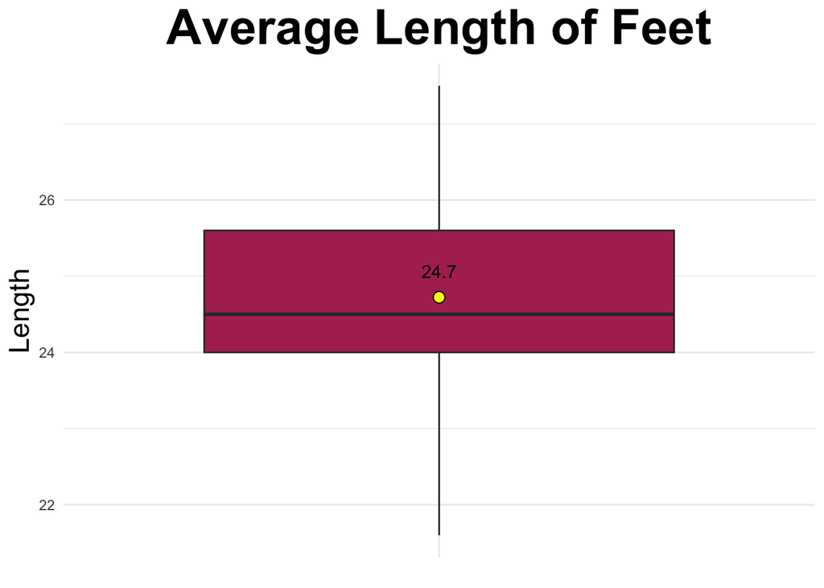

```r
# Example:

KidsFeet %>%
  ggplot(aes(x = "", y = length)) +  # Add x aesthetic to avoid errors
  geom_boxplot(fill = "maroon") +
  stat_summary(
    fun = mean,
    geom = "point",
    shape = 21,
    size = 3,
    fill = "yellow"
  ) +
  stat_summary(
    fun = mean,
    geom = "text",
    aes(label = round(after_stat(y), 1)),
    vjust = -1.5,
    color = "black"
  ) +
  labs(
    title = "Average Length of Feet",
    y = "Length",
    x = NULL  # Remove unnecessary x-axis label
  ) +
  theme_minimal() +  # Apply minimal theme first
  theme(
    plot.title = element_text(
      face = "bold",
      hjust = 0.5,  # Center title properly
      size = 30
    ),
    axis.title.y = element_text(
      size = 17
    )
  )
```

#### e. Do boys (B) or girls (G) have longer feet, on average, in the KidsFeet dataset?

###### Example:

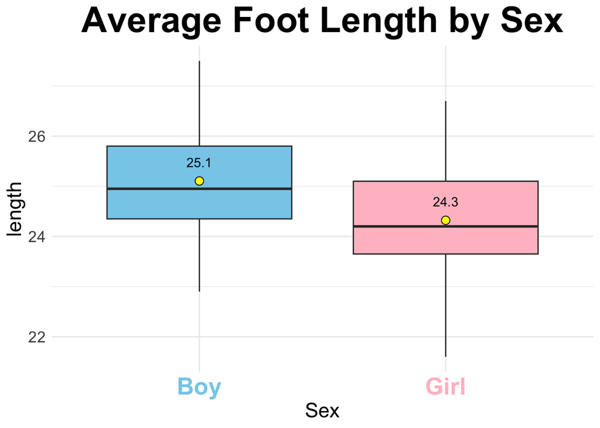

```r
# Example:
KidsFeet %>%
  ggplot(aes(x = sex, y = length, fill = sex)) +
  geom_boxplot(position = "dodge") +
  stat_summary(
    fun = mean,
    geom = "point",
    shape = 21,
    size = 3,
    fill = "yellow"
  ) +
  stat_summary(
    fun = mean,
    geom = "text",
    aes(label = round(after_stat(y), 1)),
    vjust = -1.5,
    color = "black"
  ) +
  scale_fill_manual(values = c("B" = "skyblue", "G" = "pink")) +
  labs(
    title = "Average Foot Length by Sex",
    x = "Sex",
    Y = "Length"
  ) +
  scale_x_discrete(
    labels = c("B" = "Boy", "G" = "Girl")
  ) +
  theme_minimal() +
  theme(
    plot.title = element_text(
      face = "bold",
      hjust = 0.5,
      size = 30
    ),
    axis.title.x = element_text(
      size  = 17
    ),
    axis.title.y = element_text(
      size = 17
    ),
    axis.text = element_text(
      size = 13
    ),
    axis.text.x = element_text(
      face = "bold",
      color = c("Boy" = "skyblue", "Girl" = "pink"),
      size = 20
    ),
    legend.position = "none"
  )
```

#### f. Are there certain months of the year that are associated with children having longer feet, on average, than others?

- **Data:** Categorical
- **Graphic:** Bar Graph

###### Example:

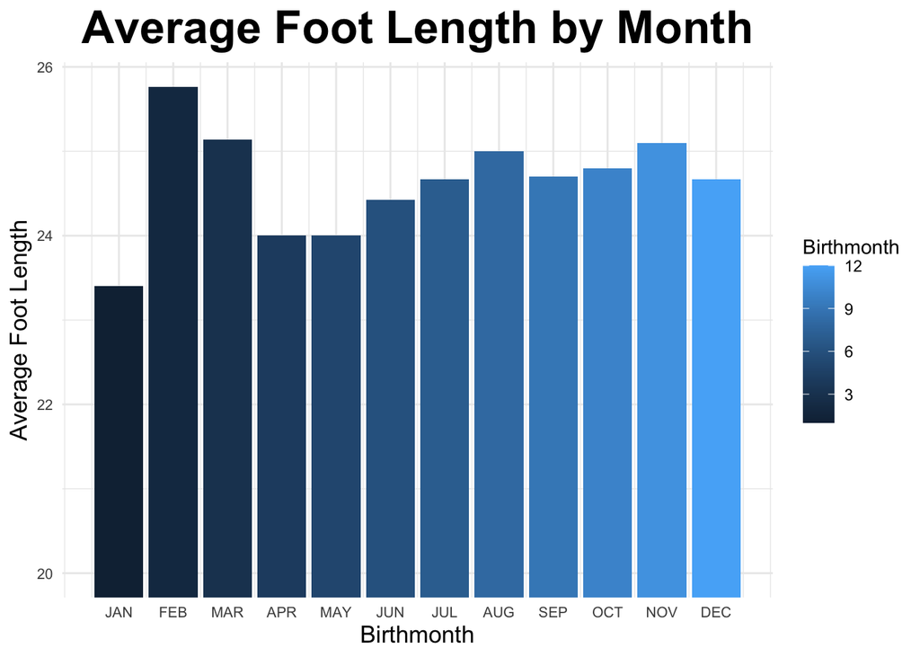

```r
# Example:

KidsFeet %>%
  group_by(birthmonth) %>%
  summarise(mean_length = mean(length, na.rm = TRUE)) %>%
  ggplot(aes(x = birthmonth, y = mean_length, fill = birthmonth)) +
  geom_col() +
  scale_x_continuous(
    breaks = 1:12,
    labels = c(
      "1" = "JAN",
      "2" = "FEB",
      "3" = "MAR",
      "4" = "APR",
      "5" = "MAY",
      "6" = "JUN",
      "7" = "JUL",
      "8" = "AUG",
      "9" = "SEP",
      "10" = "OCT",
      "11" = "NOV",
      "12" = "DEC"
    )
  ) +
  coord_cartesian(ylim = c(20, NA)) +
  labs(
    title = "Average Foot Length by Month",
    x = "Birthmonth",
    y = "Average Foot Length",
    fill = "Birthmonth"
  ) +
  theme_minimal() +
  theme(
    plot.title = element_text(
      face = "bold",
      hjust = 0.5,
      size = 25
    ),
    axis.title.x = element_text(
      size  = 13
    ),
    axis.title.y = element_text(
      size = 13
    ),
    axis.text = element_text(
      size = 8
    )
  )
```

#### g. Is there a relationship between the length of children's feet and the width of their foot?

- **Data:** Numerical
- **Graphic:** Scatterplot

###### Example:

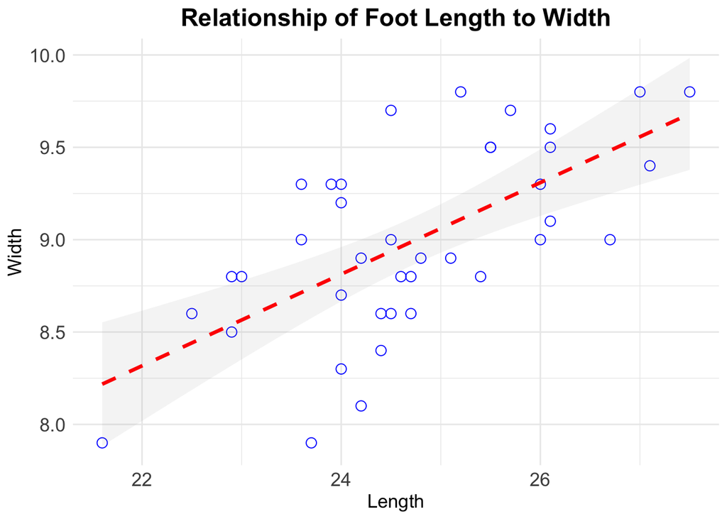

```r
# Example:

KidsFeet %>%
  ggplot(aes(x = length, y = width)) +
  geom_point(pch = 1, color = "blue", size = 3) +
  geom_smooth(method = "lm", color = "red", linetype = "dashed", linewidth = 1.2, alpha = .1) +
  labs(
    title = "Relationship of Foot Length to Width",
    x = "Length",
    y = "Width"
  ) +
  theme_minimal() +
  theme(
    plot.title = element_text(
      face = "bold",
      hjust = 0.5,
      size = 17
    ),
    axis.title.x = element_text(
      size  = 13
    ),
    axis.title.y = element_text(
      size = 13
    ),
    axis.text = element_text(
      size = 13
    )
  )
```